# Land use change (binary)

# 1 How to simulate land use change?

Replace the specific habitats to “CP” (including all species, assuming that community reached the equilibrium).

After simulating land use change, we have the duplicated links in the aggregated network.

# 2 How to aggregate binary data?

**1) Links duplication** : For each duplicated links, we calculate the direct ES provision and indirect effect on ES.

**2) Unique links** : We removed duplicated links. (equivalent to habitat loss)

# 3 Link duplication

## 3.1 Direct provision E(D)S

### 3.1.1 ES/E(D)S

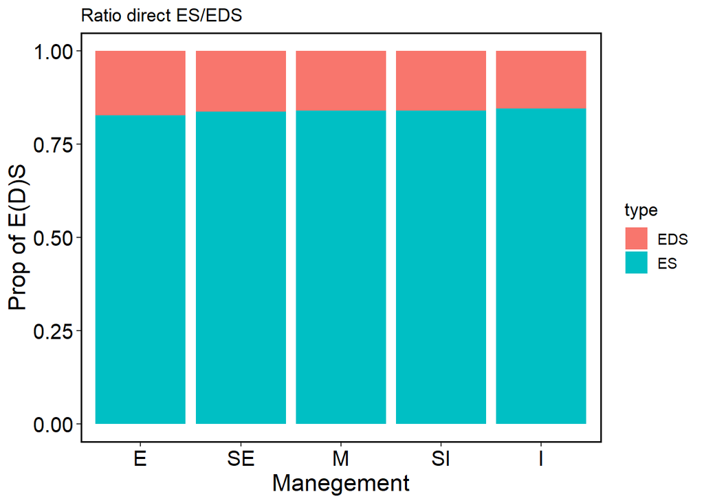

### 3.1.2 Number of EDS provided per management

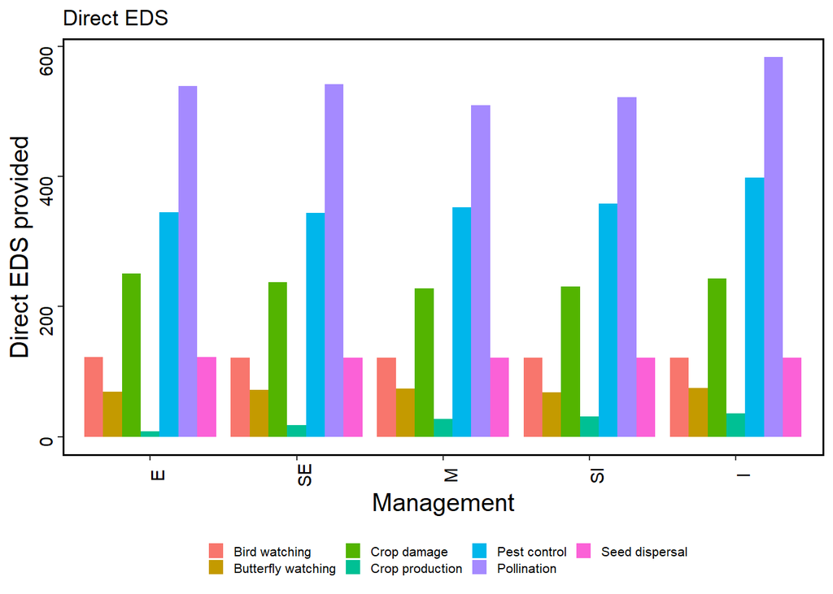

## 3.2 Indirect effect on ES

### 3.2.1 +/-

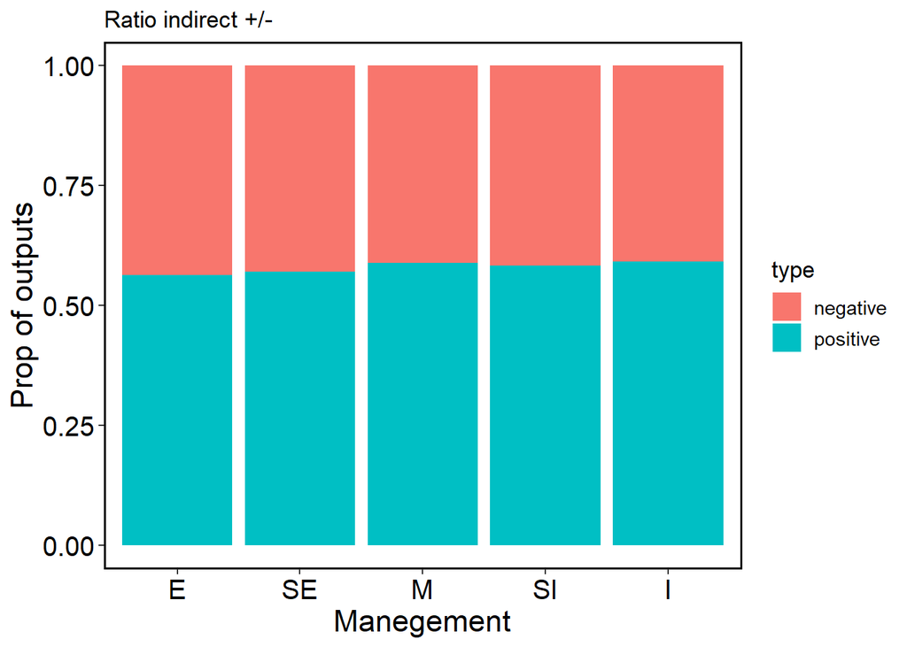

# 4 Unique links (habitat loss)

## 4.1 Direct provision E(D)S

### 4.1.1 ES/E(D)S

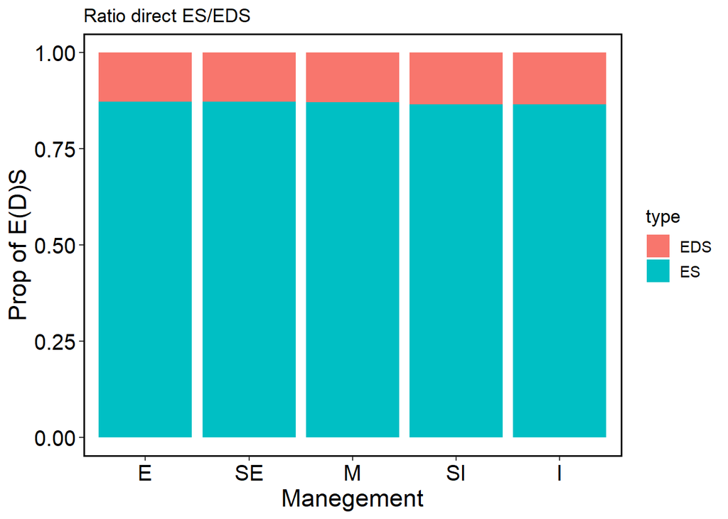

### 4.1.2 Number of EDS provided per management

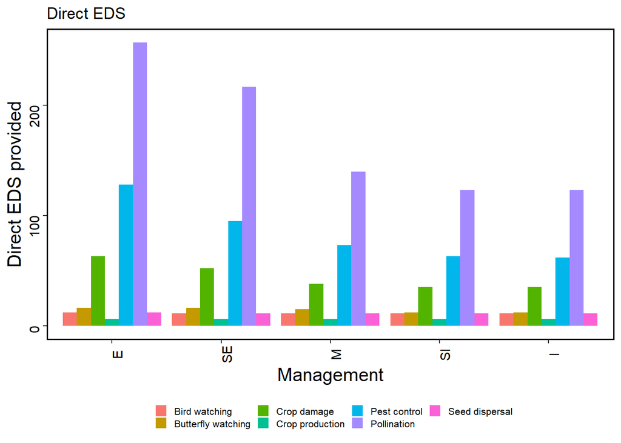

## 4.2 Indirect effect on ES

### 4.2.1 +/-

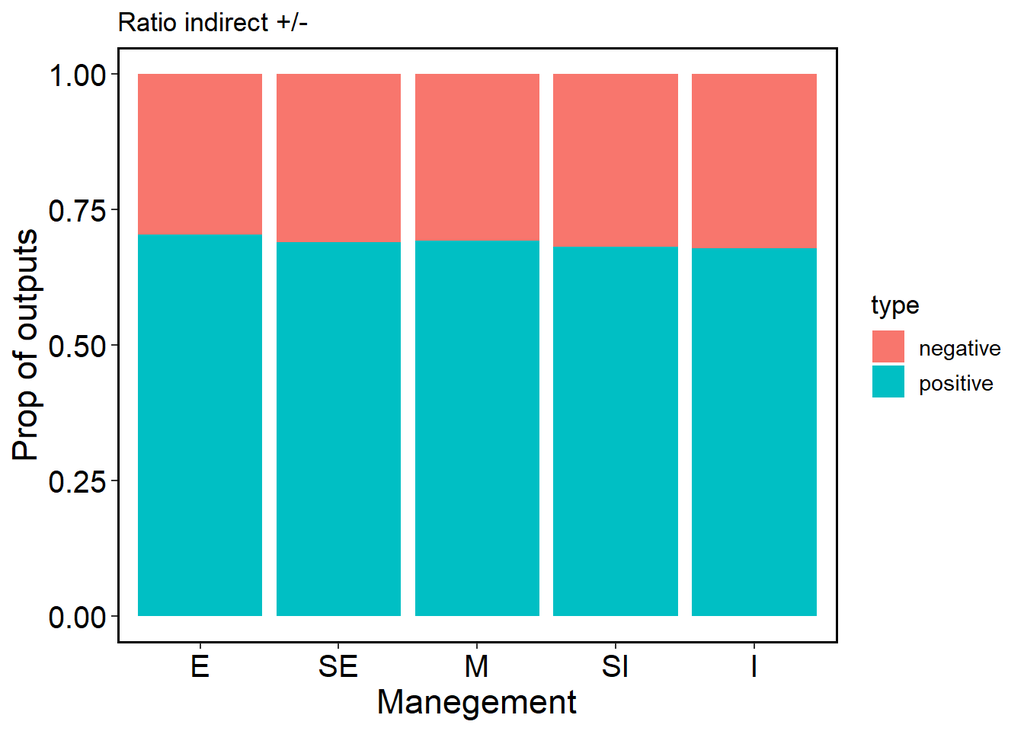

# 5 Potential causes

- CP has higher species and links richness than most habitats, so when we replace habitats to CP we are increasing the direct provision of E(D)S and the indirect effects on ES.
- Abundance - area: the results probably will change after including the species abundances and reducing it according to the area of new habitat. This allows us to avoid duplicated links.

# 6 Next steps

**Incorporate abundances of species and area of habitats**

**Steps**

**1)** Create multilayer network with abundances as state nodes attributes (nodes’ abundances per each habitat)

**2)** Change the habitats to “CP” but modifying the abundance of each species according to the area.

**3)** Aggregate the habitats to create the Norwoodfarm network. During this step, we add the abundances of the same species across habitats. Then, we calculate the weight of links between two species:

$w_{ji}=A_{j}\times A_{i}$

where $A_j$ and $A_i$ represent the relative abundance of species $j$ and $i$ in their trophic group.